# STT180 Final Project

Alice Shirley, Ethan Fremder, Jack Upton, Sally Shin

2023-04-24

# Intro

The variables contained in this dataset are pick, player name, college, years in the nba, games played, total minutes played in the NBA, total points scored in the NBA, total rebounds in the NBA, total assists recorded in the NBA, field goal -percentage, 3 point percentage, free throw percentage, win share, win share 48, plus-minus value, the value over replacement player, draft year, minutes per game, points per game, rebounds per game, and assists per game.

Three of the factors in this data set are a little confusing. These factors are win-share, value over replacement player, and plus-minus value. Win share is a number assigned to a player based on their offense, defense, and playing time. Essentially, it is a measure of how much a player contributes to a game. A higher win-share value is better. Win-shares 48 scales this value to 48 minutes of game time. Next, the plus-minus value is the net changes in score when a given player is on or off the court. Lastly, the value over replacement player, otherwise known as VORP, is the number of points that a player contributed per 100 team possessions above a replacement level player.

## Research Questions

1. Can we predict career length based on player stats?
2. What qualities of a basketball player’s performance indicate a long career?

Our goal is to investigate the data and come to a conclusion about which factors are most strongly related to the career length of players. We will back it up with plots, linear models, and other evidence. Successful linear modeling will allow us to make predictions about the length of careers of players with certain qualities. We anticipate that there will be a correlation between certain factors such as career length and points per game, and minutes per game, as a lengthy career is indicative of success in the sport.

# Methods

## Packages

We used features of several different packages to answer our research questions. Plyr, dplyr, and tidyverse were used to clean and organize our data, ggplot2 was used for all data visualization, and MASS was used to generate our models.

## Data Cleaning and Preparation

Before we could conduct any meaningful analysis, the dataset had to be cleaned and prepared. The first thing we did was use convert the column names to strings that were easier to read (e.g. ‘X3P’ became ‘three.point.pcnt’). Next, we delineated columns that would definitely not be used and dropped them from the dataframe. These included duplicate columns and a column containing a list of url to player stats. From there, we created another dataframe that featured strictly numeric values, and another that contained only the variables we deemed relevant to answering our research question. Null values were dropped from both of these data frames. The latter of the two dataframes’ content was determined by approaching the problem logically. Since the question posed was how performance indicates career length, the statistics captured over the length of a player’s career seemed irrelevant to any potential conclusion. Thus, career total statistics were dropped in favor of statistics bound by an interval (e.g. total career points scored vs. points scored per game)

Full dataframe

| id | pick | team | player | college | years | games | minutes | points | rebounds | assists | field.goal.pcnt | three.point.pcnt | free.throw.pcnt | win.shares | win.shares.48 | plus.minus | value.over.replacement.player | draft.year | minutes.per.game | points.per.game | rebounds.per.game | assists.per.game |
| --- | --- | --- | --- | --- | --- | --- | --- | --- | --- | --- | --- | --- | --- | --- | --- | --- | --- | --- | --- | --- | --- | --- |
| 1 | 1 | BRK | Derrick Coleman | Syracuse | 15 | 781 | 25903 | 12884 | 7232 | 1985 | 0.447 | 0.295 | 0.769 | 64.3 | 0.119 | 1.4 | 22.3 | 1990 | 33.2 | 16.5 | 9.3 | 2.5 |
| 2 | 2 | OKC | Gary Payton | Oregon State | 17 | 1335 | 47117 | 21813 | 5269 | 8966 | 0.466 | 0.317 | 0.729 | 145.5 | 0.148 | 3.3 | 62.5 | 1990 | 35.3 | 16.3 | 3.9 | 6.7 |
| 3 | 3 | DEN | Mahmoud Abdul-Rauf | LSU | 9 | 586 | 15628 | 8553 | 1087 | 2079 | 0.442 | 0.354 | 0.905 | 25.2 | 0.077 | -0.8 | 4.5 | 1990 | 26.7 | 14.6 | 1.9 | 3.5 |
| 4 | 4 | ORL | Dennis Scott | Georgia Tech | 10 | 629 | 17983 | 8094 | 1774 | 1296 | 0.417 | 0.397 | 0.793 | 33.4 | 0.089 | 0.2 | 9.9 | 1990 | 28.6 | 12.9 | 2.8 | 2.1 |
| 5 | 5 | CHA | Kendall Gill | Illinois | 15 | 966 | 29481 | 12914 | 4002 | 2945 | 0.434 | 0.300 | 0.754 | 47.8 | 0.078 | 0.1 | 15.8 | 1990 | 30.5 | 13.4 | 4.1 | 3.0 |
| 6 | 6 | MIN | Felton Spencer | Louisville | 12 | 640 | 12298 | 3354 | 3436 | 213 | 0.484 | 0.000 | 0.658 | 20.9 | 0.081 | -4.3 | -7.0 | 1990 | 19.2 | 5.2 | 5.4 | 0.3 |
| 7 | 7 | SAC | Lionel Simmons | La Salle | 7 | 454 | 13472 | 5833 | 2833 | 1498 | 0.433 | 0.305 | 0.771 | 16.9 | 0.060 | 0.0 | 6.7 | 1990 | 29.7 | 12.8 | 6.2 | 3.3 |
| 8 | 8 | LAC | Bo Kimble | Loyola Marymount | 3 | 105 | 1336 | 574 | 162 | 98 | 0.386 | 0.291 | 0.728 | 0.1 | 0.004 | -5.7 | -1.2 | 1990 | 12.7 | 5.5 | 1.5 | 0.9 |
| 9 | 9 | MIA | Willie Burton | Minnesota | 8 | 316 | 6666 | 3243 | 932 | 393 | 0.424 | 0.345 | 0.786 | 9.1 | 0.065 | -2.5 | -0.9 | 1990 | 21.1 | 10.3 | 2.9 | 1.2 |
| 10 | 10 | ATL | Rumeal Robinson | Michigan | 6 | 336 | 6098 | 2546 | 606 | 1179 | 0.432 | 0.344 | 0.611 | 5.2 | 0.041 | -1.5 | 0.8 | 1990 | 18.1 | 7.6 | 1.8 | 3.5 |

[output cut: 1858 more lines]

Numeric-only dataframe

| pick | years | games | minutes | points | rebounds | assists | field.goal.pcnt | three.point.pcnt | free.throw.pcnt | win.shares | win.shares.48 | plus.minus | value.over.replacement.player | draft.year | minutes.per.game | points.per.game | rebounds.per.game | assists.per.game |
| --- | --- | --- | --- | --- | --- | --- | --- | --- | --- | --- | --- | --- | --- | --- | --- | --- | --- | --- |
| 1 | 15 | 781 | 25903 | 12884 | 7232 | 1985 | 0.447 | 0.295 | 0.769 | 64.3 | 0.119 | 1.4 | 22.3 | 1990 | 33.2 | 16.5 | 9.3 | 2.5 |
| 2 | 17 | 1335 | 47117 | 21813 | 5269 | 8966 | 0.466 | 0.317 | 0.729 | 145.5 | 0.148 | 3.3 | 62.5 | 1990 | 35.3 | 16.3 | 3.9 | 6.7 |
| 3 | 9 | 586 | 15628 | 8553 | 1087 | 2079 | 0.442 | 0.354 | 0.905 | 25.2 | 0.077 | -0.8 | 4.5 | 1990 | 26.7 | 14.6 | 1.9 | 3.5 |
| 4 | 10 | 629 | 17983 | 8094 | 1774 | 1296 | 0.417 | 0.397 | 0.793 | 33.4 | 0.089 | 0.2 | 9.9 | 1990 | 28.6 | 12.9 | 2.8 | 2.1 |
| 5 | 15 | 966 | 29481 | 12914 | 4002 | 2945 | 0.434 | 0.300 | 0.754 | 47.8 | 0.078 | 0.1 | 15.8 | 1990 | 30.5 | 13.4 | 4.1 | 3.0 |
| 6 | 12 | 640 | 12298 | 3354 | 3436 | 213 | 0.484 | 0.000 | 0.658 | 20.9 | 0.081 | -4.3 | -7.0 | 1990 | 19.2 | 5.2 | 5.4 | 0.3 |
| 7 | 7 | 454 | 13472 | 5833 | 2833 | 1498 | 0.433 | 0.305 | 0.771 | 16.9 | 0.060 | 0.0 | 6.7 | 1990 | 29.7 | 12.8 | 6.2 | 3.3 |
| 8 | 3 | 105 | 1336 | 574 | 162 | 98 | 0.386 | 0.291 | 0.728 | 0.1 | 0.004 | -5.7 | -1.2 | 1990 | 12.7 | 5.5 | 1.5 | 0.9 |
| 9 | 8 | 316 | 6666 | 3243 | 932 | 393 | 0.424 | 0.345 | 0.786 | 9.1 | 0.065 | -2.5 | -0.9 | 1990 | 21.1 | 10.3 | 2.9 | 1.2 |
| 10 | 6 | 336 | 6098 | 2546 | 606 | 1179 | 0.432 | 0.344 | 0.611 | 5.2 | 0.041 | -1.5 | 0.8 | 1990 | 18.1 | 7.6 | 1.8 | 3.5 |

[output cut: 1473 more lines]

Dataframe w/ relevant statistics

| years | pick | field.goal.pcnt | three.point.pcnt | free.throw.pcnt | win.shares.48 | plus.minus | value.over.replacement.player | minutes.per.game | points.per.game | rebounds.per.game | assists.per.game |
| --- | --- | --- | --- | --- | --- | --- | --- | --- | --- | --- | --- |
| 15 | 1 | 0.447 | 0.295 | 0.769 | 0.119 | 1.4 | 22.3 | 33.2 | 16.5 | 9.3 | 2.5 |
| 17 | 2 | 0.466 | 0.317 | 0.729 | 0.148 | 3.3 | 62.5 | 35.3 | 16.3 | 3.9 | 6.7 |
| 9 | 3 | 0.442 | 0.354 | 0.905 | 0.077 | -0.8 | 4.5 | 26.7 | 14.6 | 1.9 | 3.5 |
| 10 | 4 | 0.417 | 0.397 | 0.793 | 0.089 | 0.2 | 9.9 | 28.6 | 12.9 | 2.8 | 2.1 |
| 15 | 5 | 0.434 | 0.300 | 0.754 | 0.078 | 0.1 | 15.8 | 30.5 | 13.4 | 4.1 | 3.0 |
| 12 | 6 | 0.484 | 0.000 | 0.658 | 0.081 | -4.3 | -7.0 | 19.2 | 5.2 | 5.4 | 0.3 |
| 7 | 7 | 0.433 | 0.305 | 0.771 | 0.060 | 0.0 | 6.7 | 29.7 | 12.8 | 6.2 | 3.3 |
| 3 | 8 | 0.386 | 0.291 | 0.728 | 0.004 | -5.7 | -1.2 | 12.7 | 5.5 | 1.5 | 0.9 |
| 8 | 9 | 0.424 | 0.345 | 0.786 | 0.065 | -2.5 | -0.9 | 21.1 | 10.3 | 2.9 | 1.2 |
| 6 | 10 | 0.432 | 0.344 | 0.611 | 0.041 | -1.5 | 0.8 | 18.1 | 7.6 | 1.8 | 3.5 |

[output cut: 1473 more lines]

## Plotting

Our strategy for exploring the data through visualization revolved around demonstrating the correlation between each relevant variable in the dataset. We originally used a full correlation matrix plotted as a heatmap, but opted for a more focused bar form, as the relationship between every variable was irrelevant to the project. This visualization might provide a rough idea of what to expect of our models.

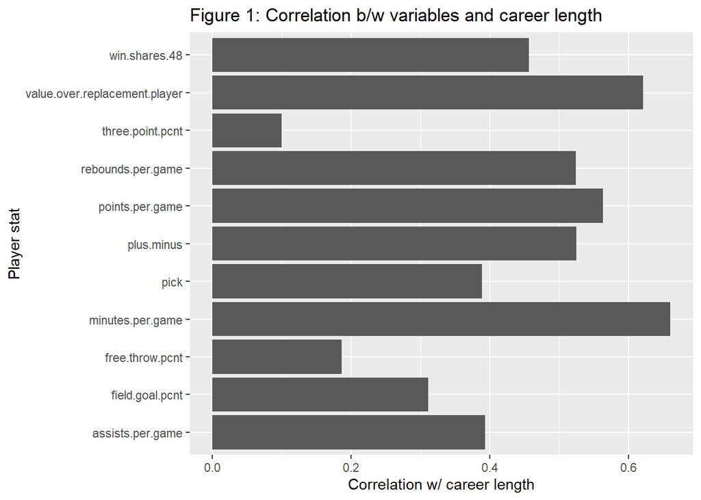

We displayed some of the more prominent correlations with career length as scatter plots with added linear regression lines to further establish the relationship between the two variables.

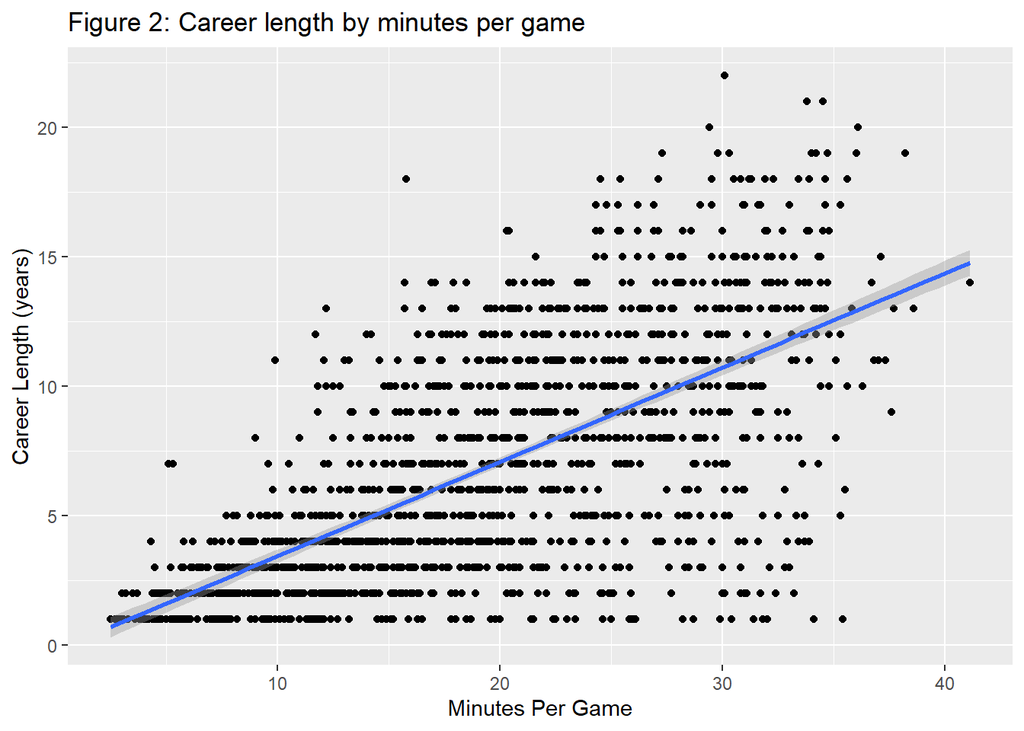

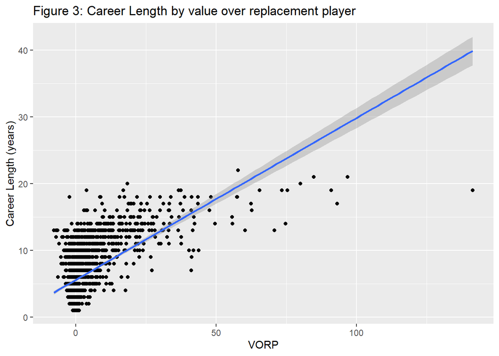

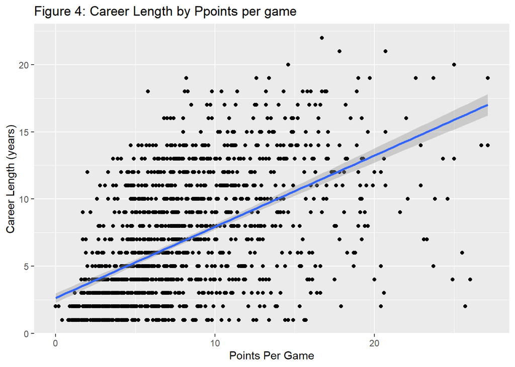

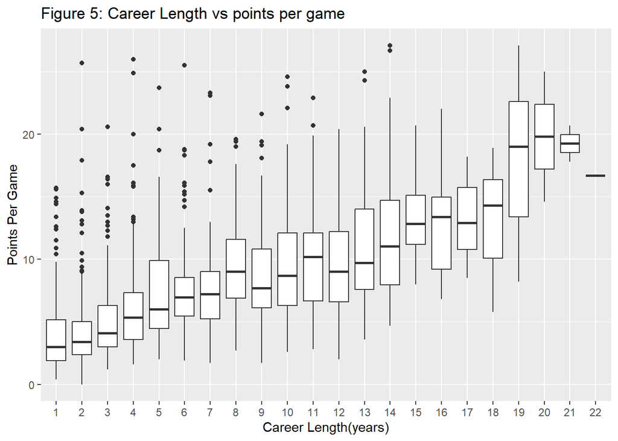

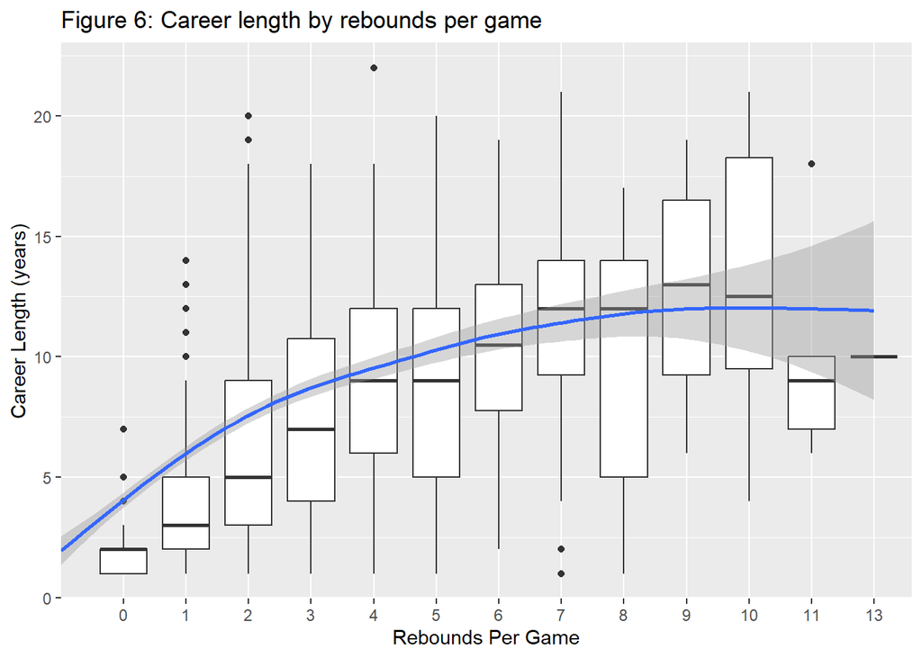

## Modeling

Armed with a solid understanding of the relationships between the important variables, we could create a linear regression model using the numeric values of the dataset.

```
##
## Call:
## lm(formula = years ~ pick + field.goal.pcnt + three.point.pcnt +
##     free.throw.pcnt + win.shares.48 + plus.minus + value.over.replacement.player +
##     minutes.per.game + points.per.game + rebounds.per.game +
##     assists.per.game, data = df.stats)
##
## Residuals:
##      Min       1Q   Median       3Q      Max
## -11.5396  -1.7782  -0.1423   1.6970  12.0189
##
## Coefficients:
##                                Estimate Std. Error t value Pr(>|t|)
## (Intercept)                    0.229181   1.125671   0.204 0.838698
## pick                          -0.020785   0.005763  -3.607 0.000321 ***
## field.goal.pcnt                1.642541   1.959824   0.838 0.402107
## three.point.pcnt              -2.258939   0.741099  -3.048 0.002344 **
## free.throw.pcnt                0.610110   0.861115   0.709 0.478740
## win.shares.48                 10.651002   3.472971   3.067 0.002203 **
## plus.minus                    -0.057036   0.075755  -0.753 0.451633
## value.over.replacement.player  0.193956   0.009519  20.377  < 2e-16 ***
## minutes.per.game               0.568671   0.026794  21.224  < 2e-16 ***
## points.per.game               -0.537920   0.042679 -12.604  < 2e-16 ***
## rebounds.per.game             -0.271673   0.071225  -3.814 0.000142 ***
## assists.per.game              -0.628787   0.088191  -7.130 1.57e-12 ***
## ---
## Signif. codes:  0 '***' 0.001 '**' 0.01 '*' 0.05 '.' 0.1 ' ' 1
##
## Residual standard error: 2.908 on 1471 degrees of freedom
## Multiple R-squared:  0.608,  Adjusted R-squared:  0.6051
## F-statistic: 207.4 on 11 and 1471 DF,  p-value: < 2.2e-16
```

This linear model was subsequently used with stepwise regression to create an optimized linear regression with as few features as possible.

```
##
## Call:
## lm(formula = years ~ pick + three.point.pcnt + win.shares.48 +
##     value.over.replacement.player + minutes.per.game + points.per.game +
##     rebounds.per.game + assists.per.game, data = df.stats)
##
## Residuals:
##      Min       1Q   Median       3Q      Max
## -11.3994  -1.7930  -0.1366   1.6744  12.0156
##
## Coefficients:
##                                Estimate Std. Error t value Pr(>|t|)
## (Intercept)                    1.612672   0.365767   4.409 1.11e-05 ***
## pick                          -0.020663   0.005755  -3.591 0.000341 ***
## three.point.pcnt              -2.433710   0.705400  -3.450 0.000576 ***
## win.shares.48                  9.884107   1.314158   7.521 9.38e-14 ***
## value.over.replacement.player  0.190552   0.009134  20.862  < 2e-16 ***
## minutes.per.game               0.568042   0.026328  21.576  < 2e-16 ***
## points.per.game               -0.531821   0.041839 -12.711  < 2e-16 ***
## rebounds.per.game             -0.269425   0.066971  -4.023 6.04e-05 ***
## assists.per.game              -0.654929   0.084988  -7.706 2.37e-14 ***
## ---
## Signif. codes:  0 '***' 0.001 '**' 0.01 '*' 0.05 '.' 0.1 ' ' 1
##
## Residual standard error: 2.907 on 1474 degrees of freedom
## Multiple R-squared:  0.6075, Adjusted R-squared:  0.6054
## F-statistic: 285.2 on 8 and 1474 DF,  p-value: < 2.2e-16
```

To test this model, a fake player was created to determine the confidence interval to which the model could predict their career length based on their performance stats.

```
##        fit      lwr      upr
## 1 11.90387 11.60085 12.20689
```

# Results

We investigated correlations to discover the relationship between career length and numerical variables. To do this, we created a correlation chart which would indicate which variables had the strongest relationship with years. From the resulting chart it is clear that the factors with the most correlation to career length are minutes per game, value over replacement player, points per game, and rebounds per game. Figures 2-6 further illustrate these relationships. The varying trends and distributions may be observed to gain further insight into how these variables relate to one another. Next, to completely affirm what we found and find the p-values, we created a full linear model with all the factors used in the correlation chart, and used the summary function. With this understanding of the dataset, we created a linear full model shows us that the factors with the smallest p-value as they relate to years are value over replacement players, minutes per game, and points per game as they have a p-value < 2e^-16. This value is extremely small and certainly smaller than .05, so we can claim that these factors are statistically significant. With a combination of low p-values and high correlation, we can conclude that MPG, PPG, and VORP are the most significant factors in predicting career length. Next, we created a step model to verify this, and determined the most important factors to be pick, VORP, RPG, MPG, APG, PPG, three point percentage, and win shares per 48 minutes of play. The inclusion of MPG, PPG, and VORP in this model confirms to us that these factors are very important.

# Conclusion

## Summary

To review, our research questions were,

1. Can we predict career length based on player stats?
2. What qualities of a basketball player’s performance indicate a long career?

## Reliability & Validity

The residuals of our model fitted with stepwise regression certainly centered around zero, as can be seen in the scatter and density plots below. However, due to the ongoing nature of the data collection (as can be seen by the diagonal cutoff in the scatterplot) it was difficult to make a finely tuned model to predict career length.

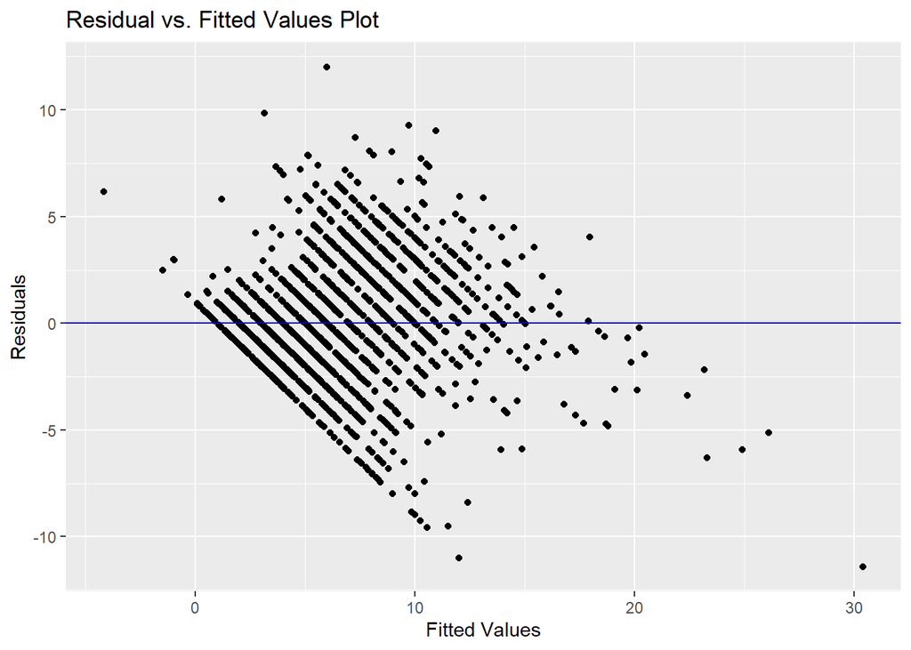

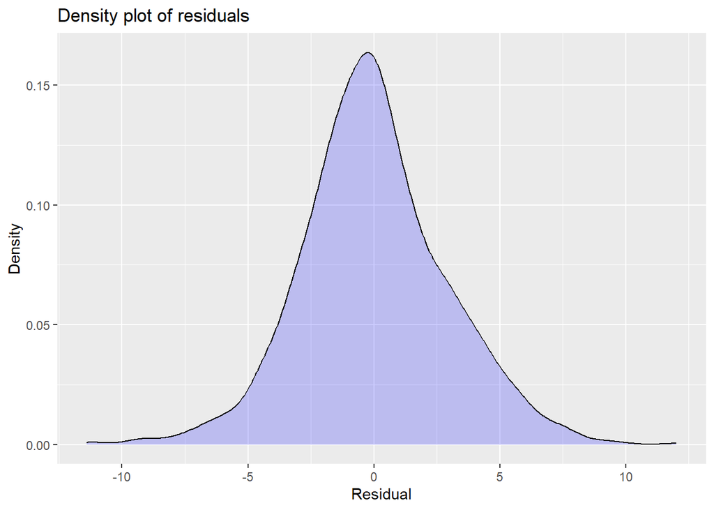

## Limitations

The largest limitation of this project was the lack of data regarding injuries. The health of a player is generally thought to be the most indicative factor of the longevity of their career, meaning we could only look at their individual performance without taking injuries and resources invested by their programs into the physical health of their players into account. Additionally, the dataset lacked information about each player’s position, which heavily lends itself to how long they play due to basketball’s physicality as a sport. Another significant limitation we encountered was the fact that the dataset only contained data from 1990-present. Although 30 years of data seems like it should be enough, since some players drafted early on in the timespan of the data are still playing and others are not, the career lengths attributed to some players are meaningless to our analysis. This is exemplified in the scatter plot below. Since we had no way to account for this when building our models, this may have interfered with the accuracy of our results.

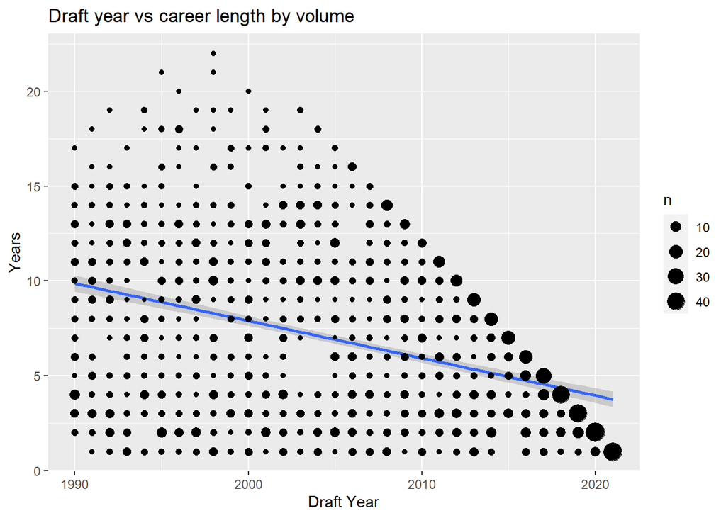

# References

Naz, M. (2022, December 30). Sky sports’ 2023 NBA Draft explained: Trades, first-round picks and lottery winnings. Sky Sports. Retrieved May 1, 2023, from https://www.skysports.com/nba/news/12040/12776816/sky-sports-2023-nba-draft-explained-trades-first-round-picks-and-lottery-winnings

NBAstuffer. (2021, September 18). WIN SHARE (Ws/48) explained. NBAstuffer. Retrieved May 1, 2023, from https://www.nbastuffer.com/analytics101/win-share/#:~:text=Win%20Share%20is%20a%20measure,to%20distribute%20among%20the%20players.%E2%80%9D

Wieland, B. (2022, February 22). 20 years of NBA Draft Data. Kaggle. Retrieved May 1, 2023, from https://www.kaggle.com/datasets/benwieland/nba-draft-data